# pheno

rachel torres

2025-01-07

## tutorial - NEON pheno packages

https://www.neonscience.org/resources/learning-hub/tutorials/phenocam-phenor-modeling

For the latest version, install `phenor` from here: https://github.com/bluegreen-labs/phenor (be sure to update all packages for installation to work, and install GenSA)

See a map of phenocam sites [here](https://phenocam.nau.edu/webcam/network/map/)

```r
# change my_site to the phenocam site you are looking at
my_site = "NEON.D16.WREF.DP1.00033"
vegtype="EN"
# can see rois to select where to download(regions of interest)
list_rois() %>%
  filter(site==my_site)
```

```
##                      site      lat       lon veg_type roi_id_number
## 1 NEON.D16.WREF.DP1.00033 45.82049 -121.9519       EN          1000
##                     description first_date  last_date site_years
## 1 canopy level EN in foreground 2018-02-01 2025-03-12        7.1
##   missing_data_pct
## 1                0
```

```r
# roi id 1000 has been around the longest with least amount of missing data, makese sense to use as example

# download phenocam - this should create 2 csv files
phenocamr::download_phenocam(
  veg_type = vegtype, #DB for decid broadleaf, EN for evergreen, default is ALL
  roi_id = 1000,
  site = my_site,
  phenophase = TRUE,
  out_dir = "." # saves in current working dir
  )
```

```
## Downloading: NEON.D16.WREF.DP1.00033_EN_1000_3day.csv
```

```
## -- Flagging outliers!
```

```
## -- Smoothing time series!
```

```
## -- Estimating transition dates!
```

The data is set up as a `phenocamr` type, which includes a list with metadata and timeseries data

## following steps from phenocamr vignette

[see website here](https://bluegreen-labs.github.io/phenocamr/articles/phenocamr-vignette.html)

source has clear steps, but uses base plotting, below I create same plot with ggplot. In this plot, the green line represents date when green up has reached 50%, and the red line represents date when 50% of gcc was lost. To see how this is calculated, check out the figures on page 6 of the phenocam access guide.

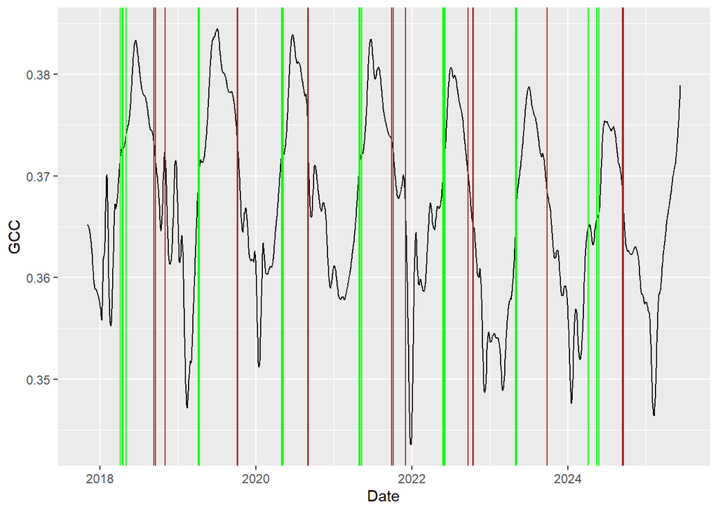

```r
# read as phenocamr type
df = read_phenocam(paste(my_site,vegtype,"1000_3day.csv", sep="_"))

df <- expand_phenocam(df) # expand every 3 day to every day

df <- detect_outliers(df) # detect outliers

df <- smooth_ts(df) # smooth data using AIC

phenology_dates <- phenophases(df, internal = TRUE) # calculate rising and falling

as.data.frame(df$data) %>%
  mutate(date = as.Date(date)) %>%
  ggplot(aes(x=date, y=smooth_gcc_90)) +
  geom_line() +
  labs(x="Date", y="GCC") +
  # rising "spring" greenup dates
  geom_vline(data=phenology_dates$rising, aes(xintercept=transition_50), col="green") +
  # falling 'autumn' senescence dates
  geom_vline(data=phenology_dates$falling, aes(xintercept=transition_50), col="brown")
```

# explore data and make plots

Find the metadata here: https://phenocam.nau.edu/webcam/tools/summary_file_format/

```r
# get data frame from larger phenocamr object
site_df = df$data

# list the column names
names(site_df)
```

```
##  [1] "date"                 "year"                 "doy"
##  [4] "image_count"          "midday_filename"      "midday_r"
##  [7] "midday_g"             "midday_b"             "midday_gcc"
## [10] "midday_rcc"           "r_mean"               "r_std"
## [13] "g_mean"               "g_std"                "b_mean"
## [16] "b_std"                "gcc_mean"             "gcc_std"
## [19] "gcc_50"               "gcc_75"               "gcc_90"
## [22] "rcc_mean"             "rcc_std"              "rcc_50"
## [25] "rcc_75"               "rcc_90"               "max_solar_elev"
## [28] "snow_flag"            "outlierflag_gcc_mean" "outlierflag_gcc_50"
## [31] "outlierflag_gcc_75"   "outlierflag_gcc_90"   "smooth_gcc_mean"
## [34] "smooth_gcc_50"        "smooth_gcc_75"        "smooth_gcc_90"
## [37] "smooth_rcc_mean"      "smooth_rcc_50"        "smooth_rcc_75"
## [40] "smooth_rcc_90"        "smooth_ci_gcc_mean"   "smooth_ci_gcc_50"
## [43] "smooth_ci_gcc_75"     "smooth_ci_gcc_90"     "smooth_ci_rcc_mean"
## [46] "smooth_ci_rcc_50"     "smooth_ci_rcc_75"     "smooth_ci_rcc_90"
## [49] "int_flag"
```

```r
# get summary values of gcc90
summary(site_df$gcc_90, na.rm=T)
```

```
##    Min. 1st Qu.  Median    Mean 3rd Qu.    Max.    NA's
##  0.3347  0.3607  0.3674  0.3671  0.3747  0.3870    1910
```

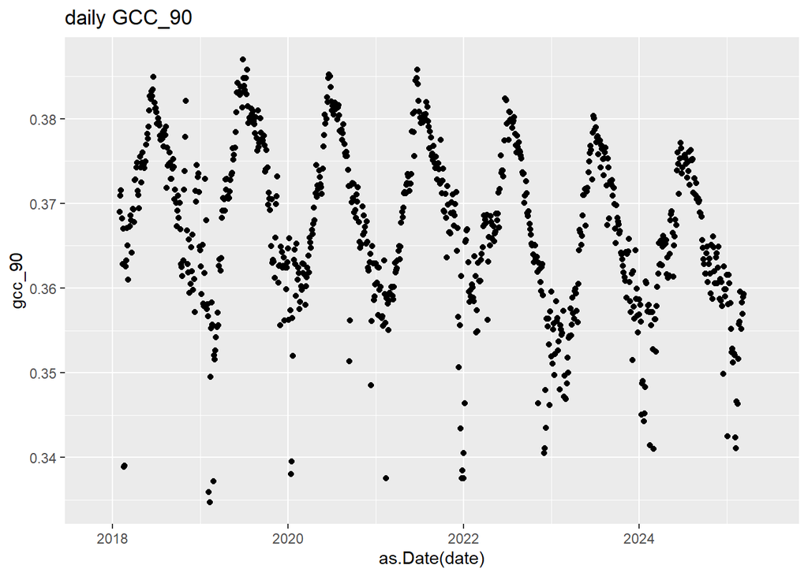

```r
# plot gcc90
ggplot(site_df, aes(x=as.Date(date), y=gcc_90)) +
  geom_point() +
  ggtitle("daily GCC_90")
```

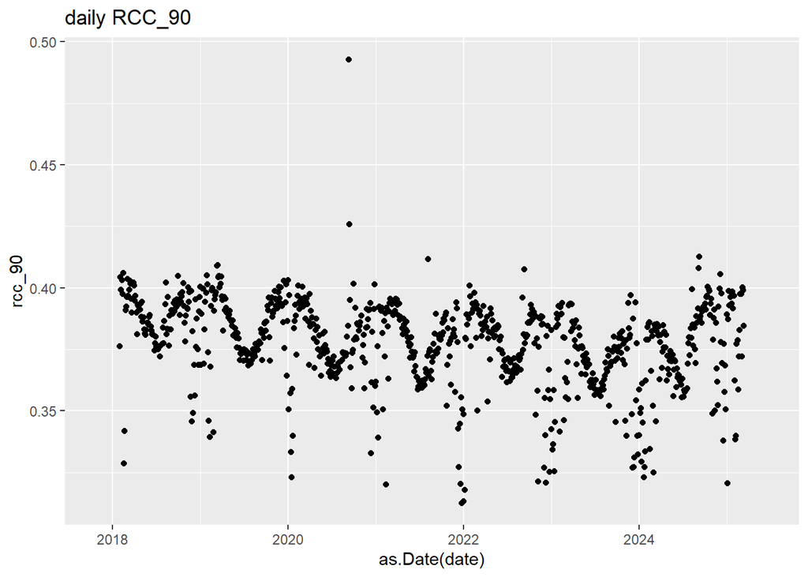

```r
# plot rcc90
ggplot(site_df, aes(x=as.Date(date), y=rcc_90)) +
  geom_point() +
  ggtitle("daily RCC_90")
```

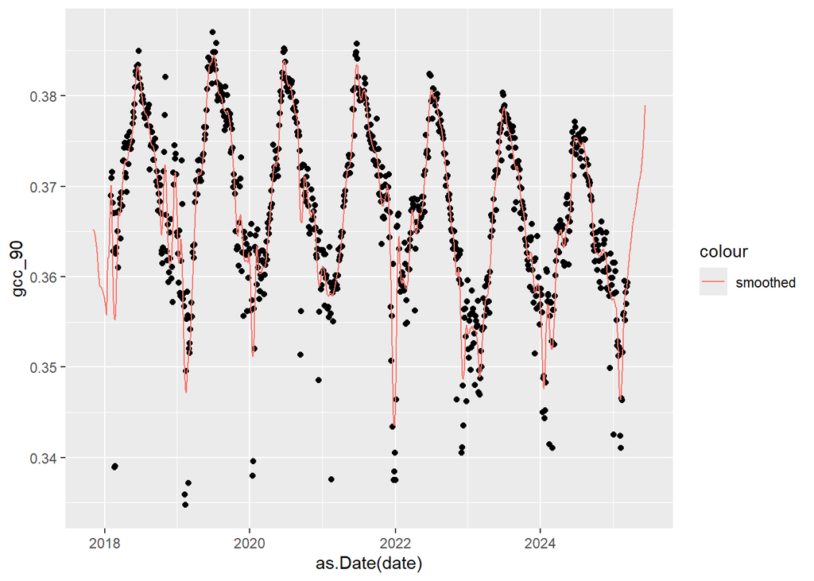

```r
# plot smoothed values
ggplot(site_df, aes(x=as.Date(date), y=gcc_90)) +
  geom_point() +
  geom_line(aes(x=as.Date(date), y=smooth_gcc_90, col="smoothed"))
```

## transition days

```r
# alternative to the above section that used the phenophases function
# load in transition days
dft = read_phenocam(paste(my_site,vegtype, "1000_3day_transition_dates.csv", sep="_"))$data

names(dft)
```

```
##  [1] "site"                   "veg_type"               "roi_id"
##  [4] "direction"              "gcc_value"              "transition_10"
##  [7] "transition_25"          "transition_50"          "transition_10_lower_ci"
## [10] "transition_25_lower_ci" "transition_50_lower_ci" "transition_10_upper_ci"
## [13] "transition_25_upper_ci" "transition_50_upper_ci" "threshold_10"
## [16] "threshold_25"           "threshold_50"           "min_gcc"
## [19] "max_gcc"
```

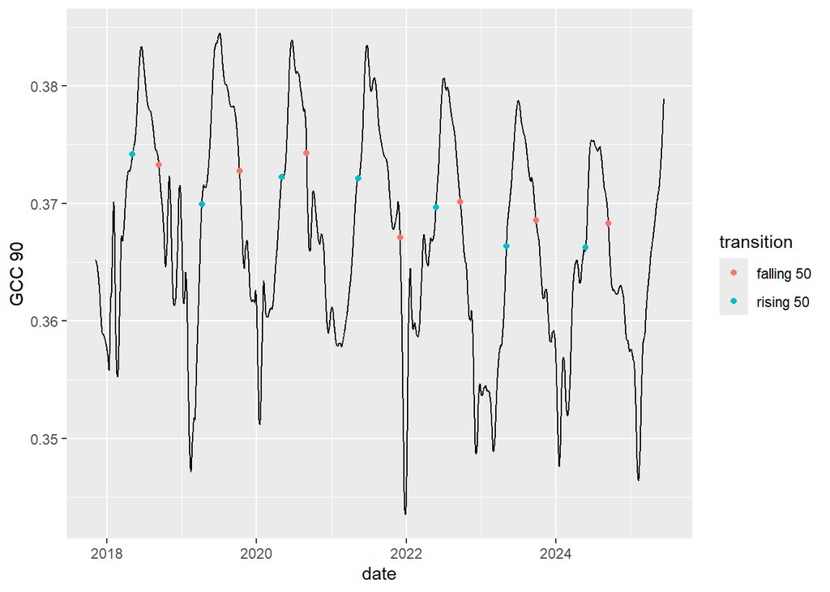

```r
# get rising and falling dates
td <- dft %>%
  dplyr::filter(direction=="rising" & gcc_value=="gcc_90")

fd <- dft %>%
  dplyr::filter(direction=="falling" & gcc_value=="gcc_90")

# create a simple line graph of the smooth Green Chromatic Coordinate (Gcc)
# and add points for transition dates
# this is same as above, but read in from the transition csv
ggplot() +
  geom_line(data=site_df, aes(x=as.Date(date), y=smooth_gcc_90)) +
  geom_point(data=td, aes(x=as.Date(transition_50), y=threshold_50, col="rising 50")) +
  geom_point(data=fd, aes(x=as.Date(transition_50), y=threshold_50, col="falling 50")) +
  labs(x="date", y="GCC 90", col="transition")
```

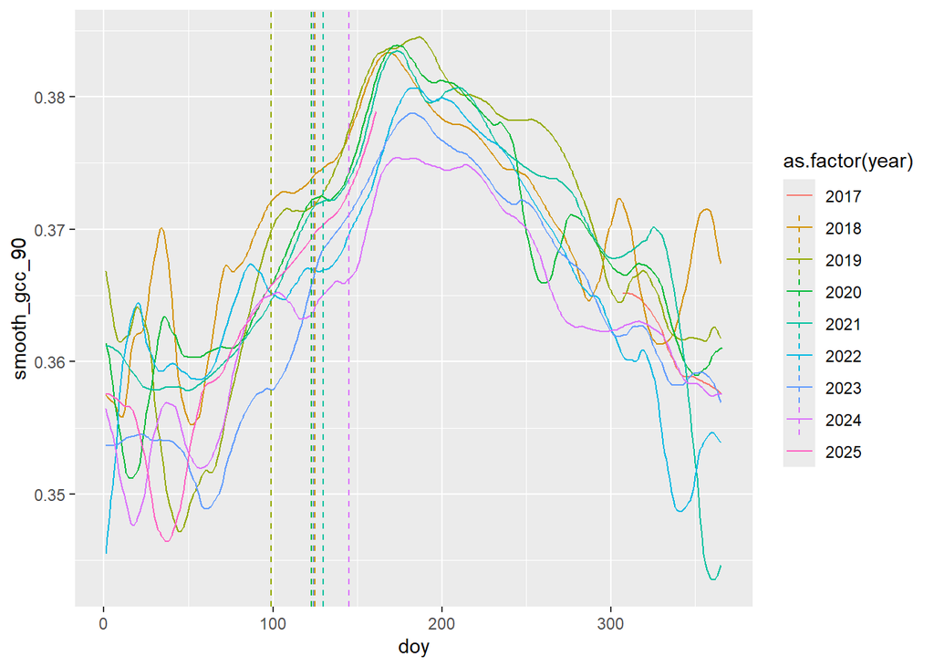

```r
# can also compare different years on same axis
# get day of year for transition dates
td_doy = td %>%
  mutate(doy_t50 = yday(transition_50),
         year = year(transition_50))

ggplot(site_df, aes(x=doy, y=smooth_gcc_90, col=as.factor(year))) +
  geom_line() +
  geom_vline(data=td_doy, aes(xintercept=doy_t50, col=as.factor(year)), linetype="dashed")
```

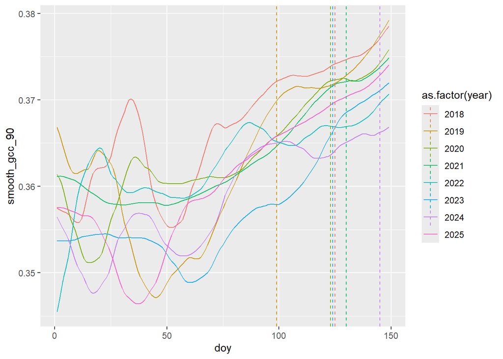

```r
# this is not a great visualization, hard to see, can try to zoom in
site_df %>% filter(doy<150) %>%
  ggplot(aes(x=doy, y=smooth_gcc_90, col=as.factor(year))) +
  geom_line() +
  geom_vline(data=td_doy, aes(xintercept=doy_t50, col=as.factor(year)), linetype="dashed")
```

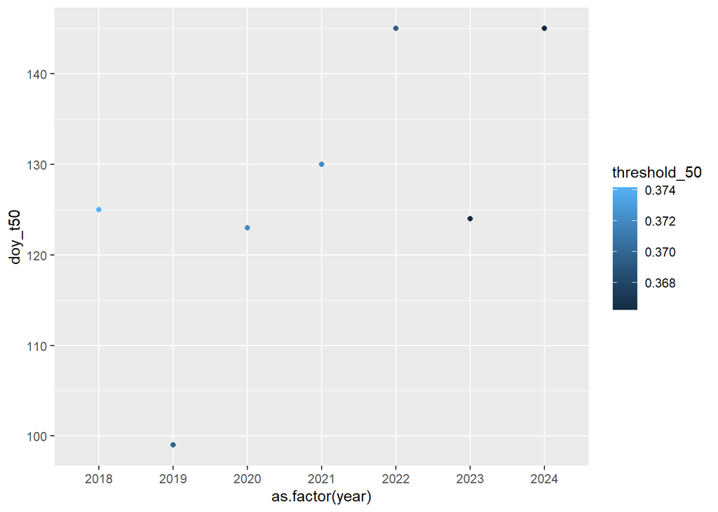

```r
# can also use transition points to plot
td_doy %>%
  ggplot(aes(x=as.factor(year), y=doy_t50)) +
  geom_point(aes(col=threshold_50))
```

## climate data: Daymet

Use the function `merge_daymet()` to get climate and daylength

Daymet is continuous, gridded estimates of weather and climate variables creted through statistical interpolation of ground based measurements. Read more here: https://daymet.ornl.gov/

```r
site_clim = merge_daymet(paste(my_site, vegtype, "1000_3day.csv", sep="_"))

names(site_clim)
```

```
##  [1] "site"           "veg_type"       "roi_id"         "frequency"
##  [5] "lat"            "lon"            "elev"           "solar_elev_min"
##  [9] "header"         "data"
```

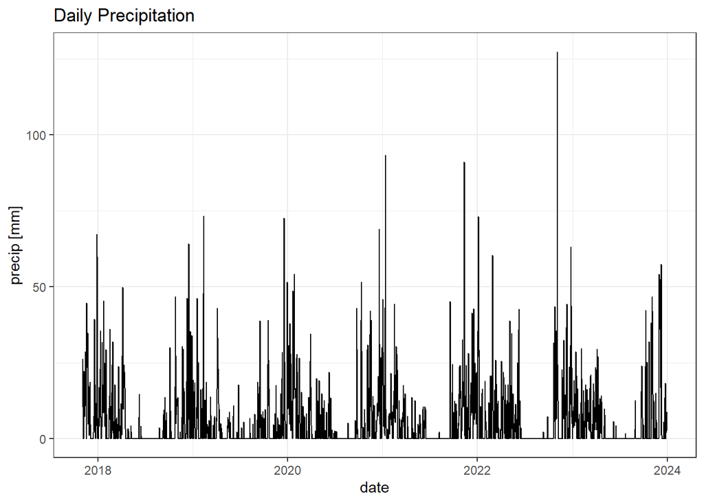

```r
site_data = site_clim$data

# plot daily rainfall and temperatures
ggplot(site_data, aes(x=date, y=prcp..mm.day.))+
  geom_line() +
  labs(y="precip [mm]", title="Daily Precipitation") +
  theme_bw()
```

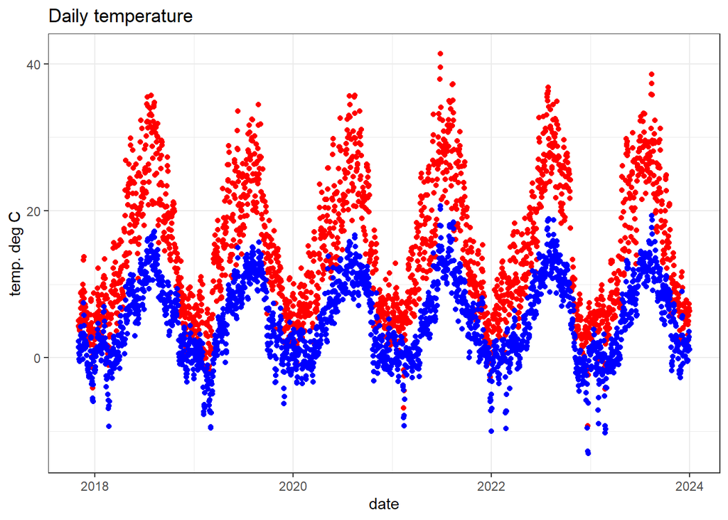

```r
ggplot(site_data) +
  geom_point(aes(x=date, y=tmax..deg.c., col="tmax"), col="red") +
  geom_point(aes(x=date, y=tmin..deg.c., col="tmin"), col="blue") +
  labs(y="temp. deg C", title = "Daily temperature") +
  theme_bw()
```

# Growing degree days

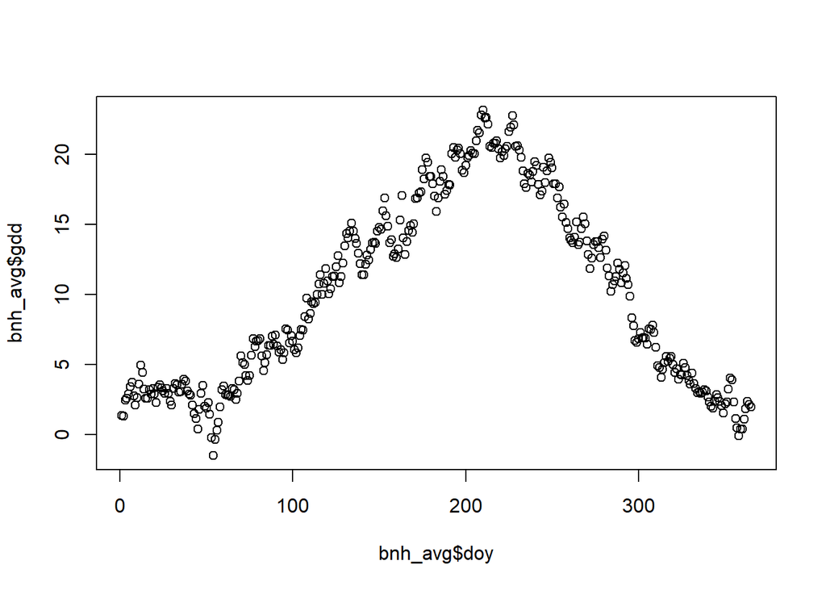

```r
site_data$tavg = (site_data$tmax..deg.c.+site_data$tmin..deg.c.)/2
site_data$gdd = site_data$tavg - 0

bnh_avg = site_data %>% group_by(doy) %>% summarize(gdd = mean(gdd))

plot(bnh_avg$doy, bnh_avg$gdd)
```

## Explore data with climate

In this example, looking at how daily values might be related to climate data. If using transition dates, would want to look at the dataframe `td_doy` and would need a climate data frame summarized be annual values to join them. More to come soon!

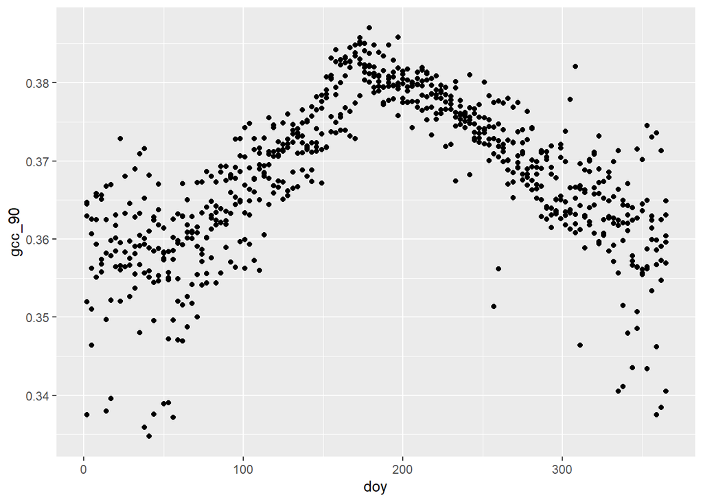

```r
# day of the year patterns
ggplot(site_data) +
  geom_point(aes(x=doy, y=gcc_90))
```

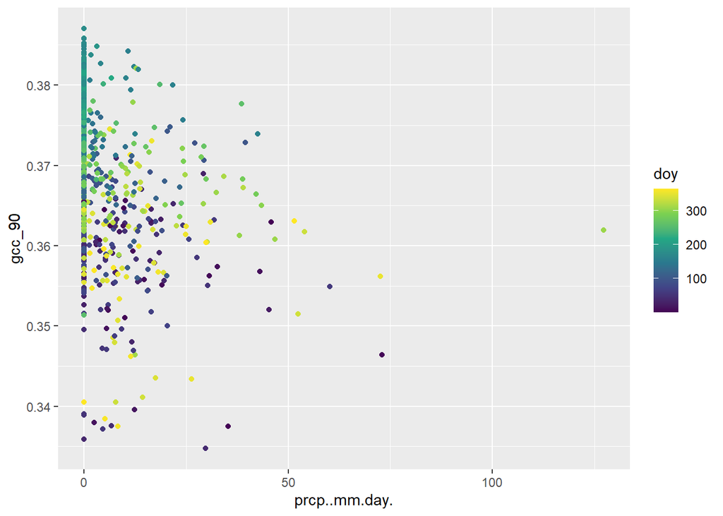

```r
# precipitation
ggplot(site_data) +
  geom_point(aes(x=prcp..mm.day., y=gcc_90, col=doy)) + scale_color_viridis_c()
```

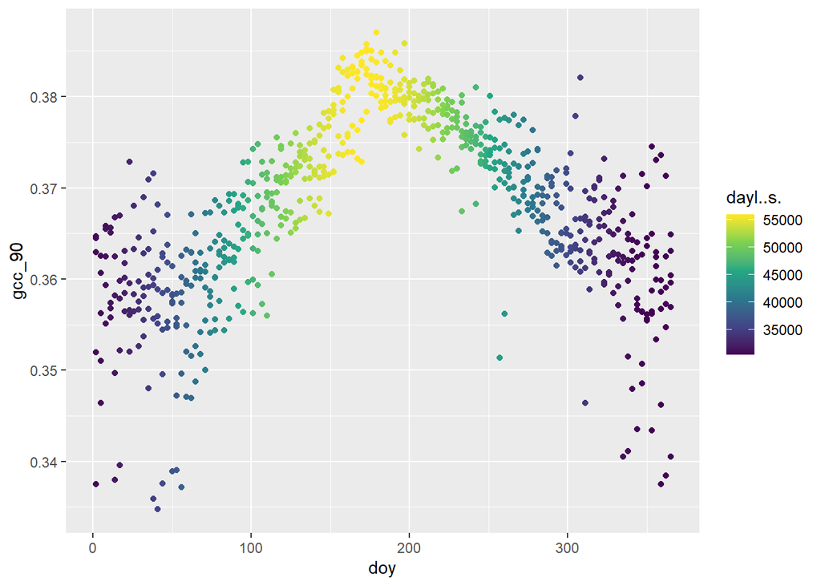

```r
# day of the year with daylength
ggplot(site_data) +
   geom_point(aes(x=doy, y=gcc_90, col=dayl..s.)) + scale_color_viridis_c()
```

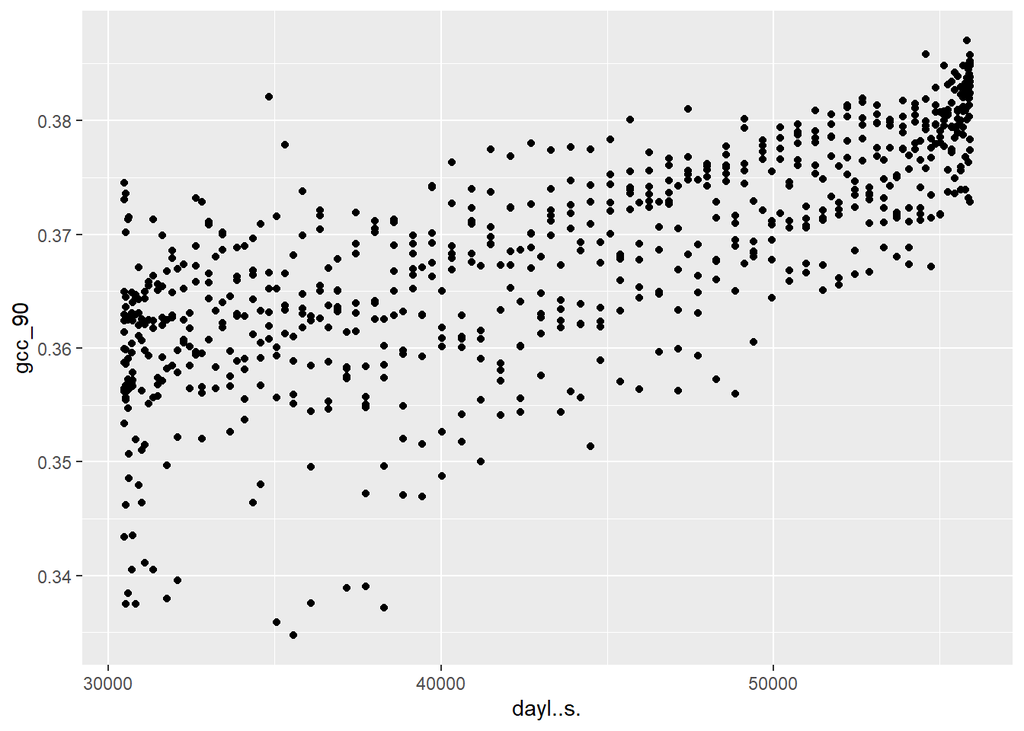

```r
# daylength
ggplot(site_data) +
  geom_point(aes(x=dayl..s., y=gcc_90))
```

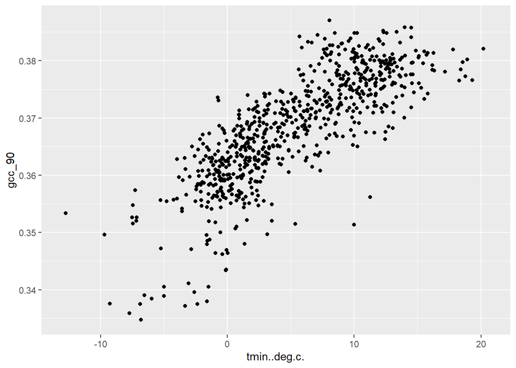

```r
# min temperatures
ggplot(site_data) +
  geom_point(aes(x=tmin..deg.c., y=gcc_90))
```

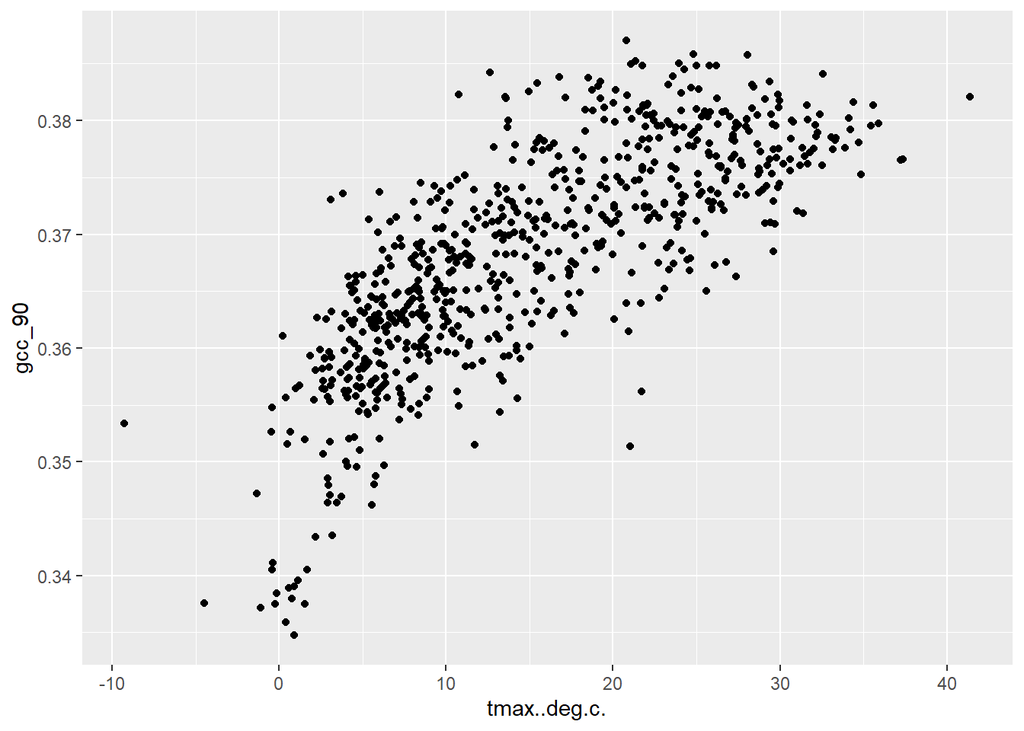

```r
# max temperatures
ggplot(site_data) +
  geom_point(aes(x=tmax..deg.c., y=gcc_90))
```

## start with time series linear model

Forecasting daily values

```r
# subset data
data_mod = site_data %>% dplyr::filter(year<2020)

# start with trying 1-2 variables
lm_test = as_tsibble(data_mod) %>%
  model(lm1=fable::TSLM(gcc_90~dayl..s.),
        lm2 = fable::TSLM(gcc_90~dayl..s.+tmin..deg.c.))
```

```
## Using `date` as index variable.
```

```r
# see residuals, p-vals, Rsquares, etc.
report(lm_test)
```

```
## # A tibble: 2 × 15
##   .model r_squared adj_r_squared  sigma2 statistic  p_value    df log_lik    AIC
##   <chr>      <dbl>         <dbl>   <dbl>     <dbl>    <dbl> <int>   <dbl>  <dbl>
## 1 lm1        0.504         0.502 4.52e-5      236. 3.48e-37     2    839. -2337.
## 2 lm2        0.715         0.713 2.61e-5      290. 1.04e-63     3    904. -2465.
## # ℹ 6 more variables: AICc <dbl>, BIC <dbl>, CV <dbl>, deviance <dbl>,
## #   df.residual <int>, rank <int>
```

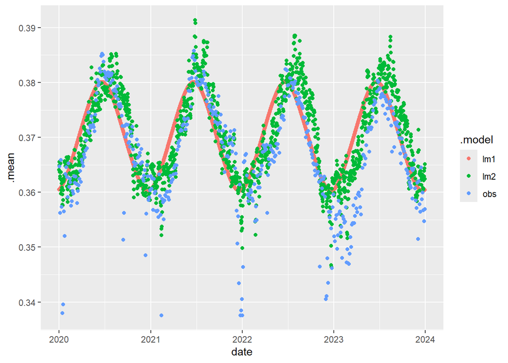

```r
# predict with remaining years
data_pred = site_data %>%
  dplyr::filter(year>=2020) %>%
  select(gcc_90, dayl..s., tmin..deg.c., year, doy, date)

# predict using fabletools::forecast function - note data must be tsibble
fc_lm <- lm_test %>%
  fabletools::forecast(
    new_data=data_pred %>%
      as_tsibble(index=date)
  )
# note that output contains distribution of gcc_90 and the mean values

# plot model
ggplot(fc_lm) +
  geom_point(aes(x=date, y=.mean, col=.model)) +
  geom_point(data=data_pred, aes(x=date, y=gcc_90, col="obs"))
```

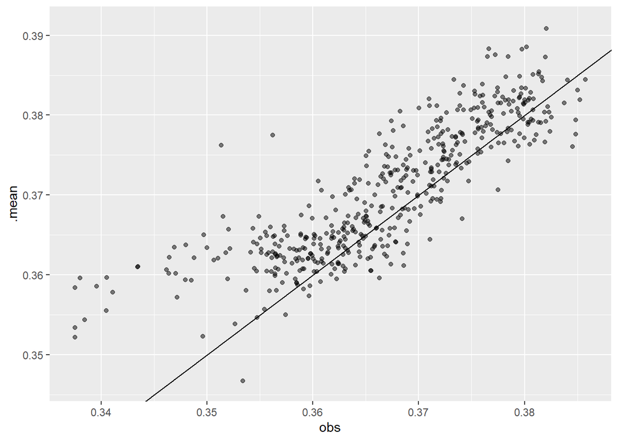

```r
# based on report and visual, model with 2 variables does better

# we can also compare to obs. with modeled
data_pred %>%
  rename(obs = gcc_90) %>%
  inner_join(fc_lm, by='date') %>%
  filter(.model=="lm2") %>%
  ggplot() + geom_point(aes(x=obs, y=.mean), alpha=0.5) +
  geom_abline(aes(slope=1, intercept=0))
```

In the above we forecasted for daily values, but what if we want to use annual metrics to predict transition dates?

## use models from phenoR package

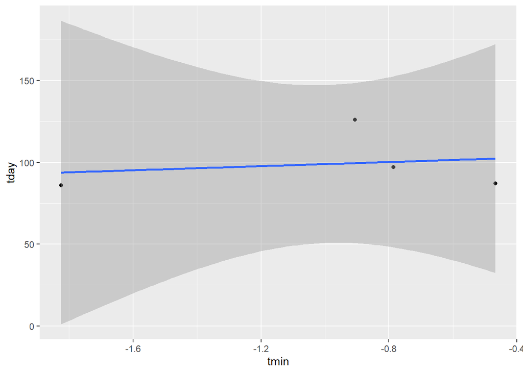

```r
# read in parameter ranges
path <- sprintf("%s/extdata/parameter_ranges.csv",path.package("phenor"))
par_ranges <- read.table(path,
                        header = TRUE,
                        sep = ",")

# estimates phenophase timing
# LIN is a linear regression against spring temps
lin_par = par_ranges %>%
  dplyr::filter(model=="LIN") %>%
  select(a,b)



# load data from phenor package - contains all decid broadleaf (DB) sites budburst data
# in proper format for models
pheno_data = phenocam_EN$windriver

pheno_data = pr_flatten(pheno_data)

# modeling spring temps v. transition dates
# format is that each column is a year
# here converting to a format we can visualize

# start data frame
spr_temps <- data.frame(pheno_data$Tmini)
# label columns
colnames(spr_temps) <- pheno_data$year
# create doy column
spr_temps$doy = as.numeric(rownames(spr_temps))

# in this chunk, we take spring temperatures, get the mean each year, and combine with the transition day vector
spr_temps_trans <- spr_temps %>%
          filter(doy>=60 & doy <=150) %>%
          pivot_longer(cols=-c(doy),
                       names_to="year",
                       values_to="tmin") %>%
  group_by(year) %>%
  summarize(tmin = mean(tmin)) %>%
  mutate(tday = pheno_data$transition_dates)

# plot the relationship we are doing a model on
ggplot(spr_temps_trans,
       aes(x=tmin, y=tday)) +
  geom_point() +
  geom_smooth(method="lm")
```

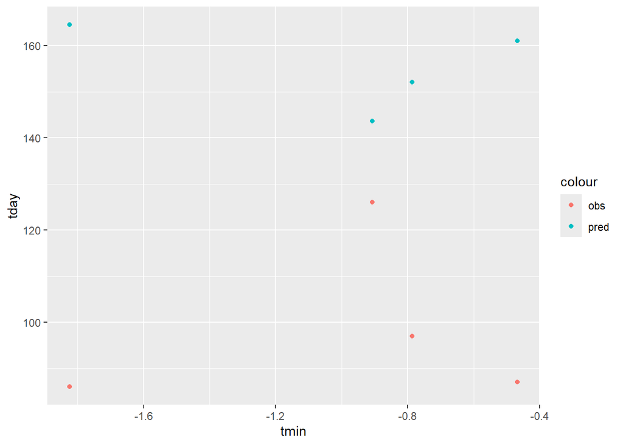

```r
# run sample lm
test = lm(tday~tmin, spr_temps_trans)

a = test$coefficients[2]
b = test$coefficients[1]

# run the linear model and get predicted transition dates
tmp = LIN(par=c(a=a, b=b), data=pheno_data, spring=c(60,150))

# add predictions
spr_temps_trans$pred_td <- tmp

# plot again with predictions to visualize
ggplot(spr_temps_trans,
       aes(x=tmin, y=tday, col="obs")) +
  geom_point() +
  geom_point(aes(x=tmin, y=pred_td, col="pred"))
```

Following this tutorial: https://www.neonscience.org/resources/learning-hub/tutorials/phenocam-phenor-modeling